# Annexe : modèle de régression logistique

Date de publication

30 août 2024

Analyse réalisée avec R version 4.2.2 Patched (2022-11-10 r83330)

# 1 Préparation des données

## 1.1 Flowchart

On se base sur le premier séjour associé à un code cancer du sein (séjour index)

```r
data_flow_start <-
data_flow |>
  as_tibble() |>
  filter(inclus,
         str_detect(liste_diag, str_u(.code$k_sein)),
         annee_source != 2019)

nrow(data_flow_start)
```

```
#> [1] 149772
```

On a bien un unique séjour par patiente (retrait des séjours secondaires antérieurs ou ultérieurs) :

```r
n_distinct(data_flow_start$ano) == nrow(data_flow_start)
```

```
#> [1] TRUE
```

soit **149772** observations indépendantes

```r
data_flow_end <-
data_flow_start |>
  mutate(codegeo = str_extract(codegeo, ".{2}"),
         region =
           case_when(codegeo %in% c("59", "62", "80", "60", "02") ~ "hdf",
                     str_starts(codegeo, "9([7-9]|[:upper:])") ~ "domtom",
                     is.na(codegeo) ~ "inconnu",
                     .default = "autre"),
         !!!.mastec) |>
  flow_filter("sexe féminin" = sexe == 2,
              "entre 18 et 99 ans" = age >= 18 & age < 100,
              "en France Métropolitaine" = region != "domtom",
              "acte de mastectomie totale ou partielle" = !is.na(mastec_final))

flow
```

```
#> $.init
#> 149772 (100.0%)
#>
#> $`sexe féminin`
#> 147955 (98.8%)
#>
#> $`entre 18 et 99 ans`
#> 147868 (98.7%)
#>
#> $`en France Métropolitaine`
#> 144615 (96.6%)
#>
#> $`acte de mastectomie totale ou partielle`
#> 82327 (55.0%)
```

Figure 1: Flowchart

[interactive chart not shown]

## 1.2 Création de variables

Variables binaires codées positivement si présence d’au moins un code associé au séjour

```r
find_code <- \(class, string) {

  atih_terminologie[[enexpr(class)]] |>
    filter(str_starts(code, string)) |>
    pull(code)

}

.code <-
list(k_sein = find_code(cim10, "C50"),
     dt2 = find_code(cim10, "E11"),
     obesite = find_code(cim10, "E66"),
     infect = find_code(cim10, "A|B"),
     meta = find_code(cim10, "C7([7-9])"),
     mastec = find_code(ccam, "QEFA0"),
     mastec_totale = find_code(ccam, "QEFA0(03|05|10|12|13|15|19|20)"),
     mastec_partielle = find_code(ccam, "QEFA0(0[1-2]|04|06|0[7-9]|11|14|1[6-8])"))
```

**Diabète (`dt2`)**

- Positif si codé dans le séjour index **OU** dans les séjours antérieurs
- Uniquement diabète de type 2

**Obésité (`obésité`)**

- Positif si codé dans le séjour index **OU** dans les séjours antérieurs
- Pas de grade associé (IMC)

**Épisode infectieux intercurrent (`infect`)**

- Recherche d’un code dans le séjour index

**Métastases (`meta`)**

- Patientes ayant un code dans le séjour index **ET PAS** dans les séjours antérieurs
- L'imputabilité au cancer du sein n'est pas déterminée, on recherche donc une découverte de métastases lors du séjour index pour compenser

**Mode d’entree**

- On considère qu'il s'agit de transferts depuis autre établissement

# 2 Spécification du modèle

**Modèle de régression logistique**

- Analyse bivariée
- Analyse multivariée : ajustement sur tous les facteurs inclus dans le modèle bivarié

## 2.1 Variable dépendante : acte de mastectomie totale vs partielle

```
#> $mastec
#> # A tibble: 3 × 2
#>   mastec     n
#>   <fct>  <int>
#> 1 Non    49500
#> 2 Oui    82327
#> 3 <NA>   12788
#>
#> $mastec_totale
#> # A tibble: 3 × 2
#>   mastec_totale      n
#>   <fct>          <int>
#> 1 Non           114711
#> 2 Oui            17116
#> 3 <NA>           12788
#>
#> $mastec_partielle
#> # A tibble: 3 × 2
#>   mastec_partielle     n
#>   <fct>            <int>
#> 1 Non              65979
#> 2 Oui              65848
#> 3 <NA>             12788
#>
#> $mastec_final
#> # A tibble: 3 × 2
#>   mastec_final     n
#>   <chr>        <int>
#> 1 Partielle    65211
#> 2 Totale       17116
#> 3 <NA>         62288
```

En faisant la somme des actes de mastectomies totales et partielles, on obtient **82964** actes, or il n’y a que **82327** observations : **637** patientes ont donc subi mastectomie partielle puis totale

Les actes successifs de mastectomie partielle puis totale chez une même patiente ont été considérés comme un acte de mastectomie totale.

```r
.count$mastec_final
```

```
#> # A tibble: 3 × 2
#>   mastec_final     n
#>   <chr>        <int>
#> 1 Partielle    65211
#> 2 Totale       17116
#> 3 <NA>         62288
```

```r
.count$mastec_final[1, 2] + .count$mastec_final[2, 2]
```

```
#>       n
#> 1 82327
```

Les observations pour lesquelles la variable mastectomie n’est pas renseignée sont ensuite supprimées

```r
df <- df_recode |> drop_na(mastec_final)

count(df, mastec_totale)
```

```
#> # A tibble: 2 × 2
#>   mastec_totale     n
#>   <fct>         <int>
#> 1 Non           65211
#> 2 Oui           17116
```

```r
count(df, mastec_final)
```

```
#> # A tibble: 2 × 2
#>   mastec_final     n
#>   <chr>        <int>
#> 1 Partielle    65211
#> 2 Totale       17116
```

Variable dépendante “acte de mastectomie totale vs partielle” : `mastec_totale`

## 2.2 Variables explicatives

Variables incluses :

```
#> $age_cat
#> [1] "Âge, années"
#>
#> $region_hdf
#> [1] "Région Hauts-de-France"
#>
#> $statut_public
#> [1] "Établissement public"
#>
#> $entree
#> [1] "Mode d'entrée"
#>
#> $dt2
#> [1] "Diabète de type 2"
#>
#> $obesite
#> [1] "Obésité"
#>
#> $infect
#> [1] "Épisode infectieux intercurrent"
#>
#> $meta
#> [1] "Métastases"
```

### 2.2.1 Hypothèse de logit-linéarité

1 variable continue : `age`

| term | OR [IC95%] | p.value |
| --- | --- | --- |
| (Intercept) | 0.25 [0.24 ; 0.26] | <0,001 |
| age_quantile(52,64] | 0.78 [0.74 ; 0.82] | <0,001 |
| age_quantile(64,72] | 0.83 [0.79 ; 0.88] | <0,001 |
| age_quantile(72,99] | 1.81 [1.73 ; 1.90] | <0,001 |

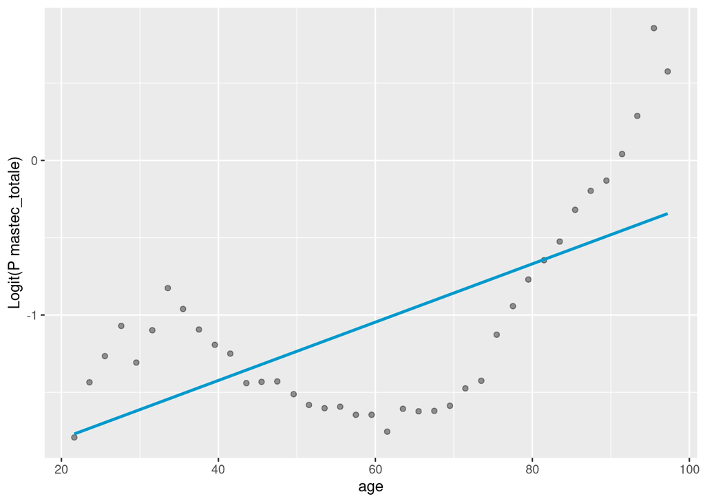

Ne semble pas y avoir de relation linéaire entre l’âge et logit de la probabilité de l’évènement : décision de transformer la variable continue `age` en une variable catégorielle, en vue de sont inclusion dans le modèle :

```r
count(df, age_cat)
```

```
#> # A tibble: 5 × 2
#>   age_cat     n
#>   <fct>   <int>
#> 1 18-49   14759
#> 2 50-59   17810
#> 3 60-69   23221
#> 4 70-79   17947
#> 5 ≥80      8590
```

### 2.2.2 Tableau descriptif

Table 1: Caractéristiques des patientes at baseline.

| **Variable** | **Overall** (N=82 327) | **Mastectomie** Totale (n=17 116, 20,8%) | **Mastectomie** Partielle (n=65 211, 79,2%) |
| --- | --- | --- | --- |
| Âge, années, médiane (IQR) | 64,0 (52,0—72,0) | 67,0 (53,0—77,0) | 63,0 (52,0—71,0) |
| Âge, années, n (%) |  |  |  |
| 18-49 | 14 759 (17,9) | 3 101 (18,1) | 11 658 (17,9) |
| 50-59 | 17 810 (21,6) | 2 969 (17,3) | 14 841 (22,8) |
| 60-69 | 23 221 (28,2) | 3 790 (22,1) | 19 431 (29,8) |
| 70-79 | 17 947 (21,8) | 3 865 (22,6) | 14 082 (21,6) |
| ≥80 | 8 590 (10,4) | 3 391 (19,8) | 5 199 (8,0) |
| Région Hauts-de-France, n (%)* | 8 155 (9,9) | 1 660 (9,7) | 6 495 (10,0) |
| Nord (59) | 3 537 (43,4) | 752 (45,3) | 2 785 (42,9) |
| Pas-de-Calais (62) | 2 022 (24,8) | 470 (28,3) | 1 552 (23,9) |
| Picardie (60) | 1 041 (12,8) | 176 (10,6) | 865 (13,3) |
| Somme (80) | 893 (11,0) | 116 (7,0) | 777 (12,0) |
| Aisne (02) | 662 (8,1) | 146 (8,8) | 516 (7,9) |
| Établissement public, n (%) | 45 889 (55,7) | 10 158 (59,3) | 35 731 (54,8) |
| Mode d'entrée, n (%) |  |  |  |
| Domicile | 82 058 (99,7) | 17 011 (99,4) | 65 047 (99,7) |
| Transfert ou mutation† | 97 (0,1) | 45 (0,3) | 52 (0,1) |
| Urgences | 172 (0,2) | 60 (0,4) | 112 (0,2) |
| Diabète de type 2, n (%)‡ | 3 765 (4,6) | 1 104 (6,5) | 2 661 (4,1) |
| Obésité, n (%)‡ | 5 710 (6,9) | 1 417 (8,3) | 4 293 (6,6) |
| Épisode infectieux intercurrent, n (%) | 510 (0,6) | 228 (1,3) | 282 (0,4) |
| Métastases, n (%)<sup>§</sup> | 14 220 (17,3) | 4 654 (27,2) | 9 566 (14,7) |

Les actes successifs de mastectomie partielle puis totale chez une même patiente sont considérés comme un acte de mastectomie totale. IQR : intervalle interquartile.  
* Pourcentage des sous-catégories calculé sur la base de l'effectif total de la région.  
† Depuis un autre établissement.  
‡ Diagnostiqué lors du séjour index ou d'un séjour antérieur.  
<sup>§</sup> Découverte d'au moins un site métastatique lors du séjour index, toutes localisations confondues.

Variables mode d’entrée (`entree`) et épisode infectieux (`infect`) : répartition des effectifs suspecte mais raison non déterminée, je les ai donc conservées pour le modèle

# 3 Création du modèle

```r
model
```

```
#> $data
#> # A tibble: 82,327 × 163
#>    type_enregistrement annee date_entree duree date_sortie mois_sortie
#>    <fct>               <int> <chr>       <int> <chr>       <chr>
#>  1 mco                  2017 10/11/2017      5 15/11/2017  11
#>  2 mco                  2018 15/05/2018      0 15/05/2018  05
#>  3 mco                  2018 10/10/2018      5 15/10/2018  10
#>  4 mco                  2017 13/01/2017      2 15/01/2017  01
#>  5 mco                  2017 15/06/2017      0 15/06/2017  06
#>  6 mco                  2018 15/06/2018      0 15/06/2018  06
#>  7 mco                  2017 14/08/2017      1 15/08/2017  08
#>  8 mco                  2017 15/07/2017      0 15/07/2017  07
#>  9 mco                  2017 15/06/2017      0 15/06/2017  06
#> 10 mco                  2017 15/08/2017      0 15/08/2017  08
#> # ℹ 82,317 more rows
#> # ℹ 157 more variables: annee_sortie <int>, finess <chr>, ghm <chr>, dp <chr>,
#> #   dr <chr>, sexe <int>, entree_mode <dbl>, entree_prov <chr>,
#> #   sortie_mode <chr>, sortie_dest <chr>, typ_sej <chr>, codegeo <chr>,
#> #   age <int>, age_cat <fct>, agejour <int>, nbActe <int>, nbEtape <int>,
#> #   nbSeance <int>, poids <int>, nbjrea <int>, nbjsi <int>, nbjsc <int>,
#> #   age_gest <int>, lit_palliatif <int>, typ_porg <int>, liste_act <chr>, …
#>
#> $y
#> [1] "mastec_totale"
#>
#> $x
#> [1] "age_cat"       "region_hdf"    "statut_public" "entree"
#> [5] "dt2"           "obesite"       "infect"        "meta"
#>
#> $recipe
#> mastec_totale ~ age_cat + region_hdf + statut_public + entree +
#>     dt2 + obesite + infect + meta
#> <environment: 0x55a9f2634138>
#>
#> $mv
#>
#> Call:  glm(formula = recipe, family = binomial, data = data)
#>
#> Coefficients:
#>                 (Intercept)                 age_cat50-59
```

[output cut: 39 more lines]

```
#> $cv
#> #  10-fold cross-validation using stratification
#> # A tibble: 10 × 2
#>    splits               id
#>    <list>               <chr>
#>  1 <split [74093/8234]> Fold01
#>  2 <split [74094/8233]> Fold02
#>  3 <split [74094/8233]> Fold03
#>  4 <split [74094/8233]> Fold04
#>  5 <split [74094/8233]> Fold05
#>  6 <split [74094/8233]> Fold06
#>  7 <split [74095/8232]> Fold07
#>  8 <split [74095/8232]> Fold08
#>  9 <split [74095/8232]> Fold09
#> 10 <split [74095/8232]> Fold10
```

Nombre d’observations contenant a minima 1 donnée manquante :

```r
model$data[, model$x] |>
  filter(if_any(everything(), is.na)) |>
  nrow()
```

```
#> [1] 0
```

## 3.1 Conditions de validité du modèle

On rappelle que chaque ligne correspond un sujet différent et qu’on suppose l’indépendance des observations

### 3.1.1 Recherche de multicollinéarité

```r
performance::check_collinearity(model$mv)
```

```
#> # Check for Multicollinearity
#>
#> Low Correlation
#>
#>           Term  VIF   VIF 95% CI Increased SE Tolerance Tolerance 95% CI
#>        age_cat 1.03 [1.03, 1.04]         1.02      0.97     [0.96, 0.97]
#>     region_hdf 1.00 [1.00, 1.03]         1.00      1.00     [0.97, 1.00]
#>  statut_public 1.01 [1.00, 1.02]         1.00      0.99     [0.98, 1.00]
#>         entree 1.01 [1.01, 1.02]         1.01      0.99     [0.98, 0.99]
#>            dt2 1.06 [1.05, 1.07]         1.03      0.94     [0.94, 0.95]
#>        obesite 1.05 [1.04, 1.06]         1.02      0.95     [0.95, 0.96]
#>         infect 1.01 [1.01, 1.02]         1.01      0.99     [0.98, 0.99]
#>           meta 1.01 [1.01, 1.02]         1.01      0.99     [0.98, 0.99]
```

### 3.1.2 Recherche d’observations influentes : distances de Cook

```
#> $data
#> # A tibble: 82,327 × 16
#>    id    mastec_totale age_cat region_hdf statut_public entree   dt2   obesite
#>    <chr> <fct>         <fct>   <fct>      <fct>         <fct>    <fct> <fct>
#>  1 1     Oui           ≥80     Non        Non           Domicile Oui   Non
#>  2 2     Non           18-49   Non        Oui           Domicile Non   Non
#>  3 3     Non           ≥80     Non        Non           Domicile Oui   Non
#>  4 4     Non           60-69   Non        Oui           Domicile Non   Non
#>  5 5     Non           18-49   Non        Oui           Domicile Non   Non
#>  6 6     Non           70-79   Non        Oui           Domicile Non   Non
#>  7 7     Non           70-79   Non        Non           Domicile Non   Non
#>  8 8     Non           18-49   Non        Oui           Domicile Non   Non
#>  9 9     Non           18-49   Non        Oui           Domicile Non   Non
#> 10 10    Non           60-69   Non        Oui           Domicile Non   Non
#> # ℹ 82,317 more rows
#> # ℹ 8 more variables: infect <fct>, meta <fct>, .fitted <dbl>, .resid <dbl>,
#> #   .hat <dbl>, .sigma <dbl>, .cooksd <dbl>, .std.resid <dbl>
#>
#> $limit
#>          inf          sup
#> 4.858673e-05 3.036671e-04
#>
#> $obs
#> $obs$inf
#> # A tibble: 3,673 × 16
#>    id    mastec_totale age_cat region_hdf statut_public entree   dt2   obesite
#>    <chr> <fct>         <fct>   <fct>      <fct>         <fct>    <fct> <fct>
#>  1 1     Oui           ≥80     Non        Non           Domicile Oui   Non
#>  2 26    Oui           60-69   Non        Non           Domicile Non   Oui
#>  3 45    Oui           ≥80     Non        Non           Domicile Oui   Oui
#>  4 47    Oui           50-59   Oui        Non           Domicile Non   Non
#>  5 88    Oui           18-49   Non        Non           Domicile Oui   Non
#>  6 106   Oui           50-59   Non        Oui           Domicile Oui   Oui
#>  7 130   Oui           70-79   Oui        Oui           Domicile Non   Non
#>  8 150   Oui           70-79   Non        Oui           Domicile Non   Oui
#>  9 169   Oui           18-49   Oui        Oui           Domicile Non   Non
#> 10 170   Oui           70-79   Oui        Oui           Domicile Non   Non
#> # ℹ 3,663 more rows
#> # ℹ 8 more variables: infect <fct>, meta <fct>, .fitted <dbl>, .resid <dbl>,
#> #   .hat <dbl>, .sigma <dbl>, .cooksd <dbl>, .std.resid <dbl>
#>
#> $obs$sup
#> # A tibble: 254 × 16
#>    id    mastec_totale age_cat region_hdf statut_public entree     dt2   obesite
#>    <chr> <fct>         <fct>   <fct>      <fct>         <fct>      <fct> <fct>
#>  1 365   Non           50-59   Oui        Oui           Transfert… Non   Non
#>  2 761   Oui           50-59   Oui        Oui           Domicile   Non   Non
#>  3 2001  Non           ≥80     Non        Non           Urgences   Non   Non
#>  4 2061  Oui           ≥80     Non        Non           Urgences   Non   Non
#>  5 2358  Non           60-69   Non        Oui           Transfert… Non   Oui
#>  6 2377  Non           ≥80     Non        Oui           Urgences   Non   Non
#>  7 2700  Oui           18-49   Non        Non           Domicile   Non   Non
#>  8 2782  Non           ≥80     Non        Oui           Urgences   Non   Non
#>  9 2834  Non           ≥80     Non        Non           Transfert… Non   Non
#> 10 3129  Non           60-69   Non        Oui           Urgences   Non   Non
#> # ℹ 244 more rows
#> # ℹ 8 more variables: infect <fct>, meta <fct>, .fitted <dbl>, .resid <dbl>,
#> #   .hat <dbl>, .sigma <dbl>, .cooksd <dbl>, .std.resid <dbl>
#>
#>
#> $plot
```

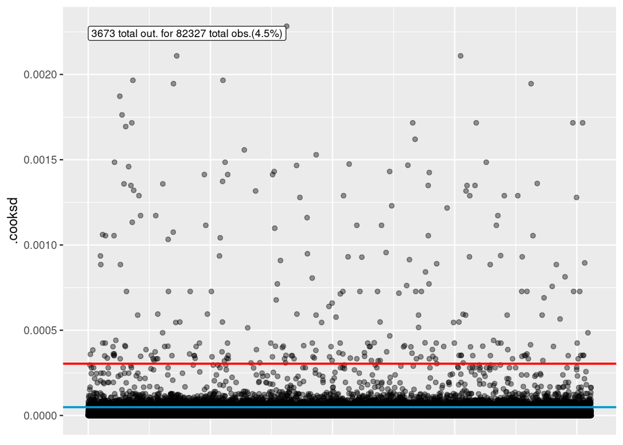

```r
cooksd(model$mv)
```

Pour les variables “limites” `entree` et `infect`, je constate que la majorite voire totalite des modalités à très faibles effectifs est représentée par les individus jugés influents :

| entree | influent | total |
| --- | --- | --- |
| Domicile | 3404 | 82058 |
| Transfert ou mutation | 97 | 97 |
| Urgences | 172 | 172 |

| infect | influent | total |
| --- | --- | --- |
| Non | 3203 | 81817 |
| Oui | 470 | 510 |

Ce qui peut sembler logique : si ces modalités sont considérés comme des caractéristiques “rares”, alors les observations porteuses de ces caractéristiques sont systématiquement considérées comme déviantes ?

Si c’est le cas c’est un peu biaisé non ? je n’ai pas l’expérience suffisante pour trancher, dans le doute les observations ont été **conservées**

## 3.2 Tableau de régression

Table 2: Modèles bivarié et multivarié de régression logistique expliquant la réalisation d’un acte de mastectomie totale vs partielle.

| **Variable** | **Analyse bivariée** **Events/Obs** | **Analyse bivariée** **OR [IC95%]** | **Analyse bivariée** **p** | **Analyse multivariée** **aOR [IC95%]** | **Analyse multivariée** **p*** |
| --- | --- | --- | --- | --- | --- |
| Âge, années |  |  | <0,001 |  | <0,001 |
| 18-49 | 3101/14759 | — |  | — |  |
| 50-59 | 2969/17810 | 0,75 [0,71 ; 0,80] |  | 0,77 [0,72 ; 0,81] |  |
| 60-69 | 3790/23221 | 0,73 [0,70 ; 0,77] |  | 0,75 [0,71 ; 0,79] |  |
| 70-79 | 3865/17947 | 1,03 [0,98 ; 1,09] |  | 1,06 [1,00 ; 1,12] |  |
| ≥80 | 3391/8590 | 2,45 [2,31 ; 2,60] |  | 2,45 [2,31 ; 2,60] |  |
| Région Hauts-de-France |  |  | 0,31 |  | 0,55 |
| Non | 15456/74172 | — |  | — |  |
| Oui | 1660/8155 | 0,97 [0,92 ; 1,03] |  | 0,98 [0,93 ; 1,04] |  |
| Établissement public |  |  | <0,001 |  | <0,001 |
| Non | 6958/36438 | — |  | — |  |
| Oui | 10158/45889 | 1,20 [1,16 ; 1,25] |  | 1,27 [1,22 ; 1,31] |  |
| Mode d'entrée |  |  | <0,001 |  | <0,001 |
| Domicile | 17011/82058 | — |  | — |  |
| Transfert ou mutation† | 45/97 | 3,31 [2,21 ; 4,93] |  | 2,52 [1,65 ; 3,82] |  |
| Urgences | 60/172 | 2,05 [1,49 ; 2,79] |  | 1,30 [0,93 ; 1,80] |  |
| Diabète de type 2‡ |  |  | <0,001 |  | <0,001 |
| Non | 16012/78562 | — |  | — |  |
| Oui | 1104/3765 | 1,62 [1,51 ; 1,74] |  | 1,32 [1,22 ; 1,43] |  |
| Obésité‡ |  |  | <0,001 |  | <0,001 |
| Non | 15699/76617 | — |  | — |  |
| Oui | 1417/5710 | 1,28 [1,20 ; 1,36] |  | 1,18 [1,10 ; 1,26] |  |
| Épisode infectieux intercurrent |  |  | <0,001 |  | <0,001 |
| Non | 16888/81817 | — |  | — |  |
| Oui | 228/510 | 3,11 [2,61 ; 3,70] |  | 2,33 [1,93 ; 2,80] |  |
| Métastases<sup>§</sup> |  |  | <0,001 |  | <0,001 |
| Non | 12462/68107 | — |  | — |  |
| Oui | 4654/14220 | 2,17 [2,09 ; 2,26] |  | 2,18 [2,09 ; 2,27] |  |

L'évènement est défini par la réalisation d'un acte de mastectomie totale. Les actes successifs de mastectomie partielle puis totale chez une même patiente sont considérés comme un acte de mastectomie totale. Modèle de régression logistique multivarié incluant 82327 observations, aucune observation contenant a minima une données manquante. OR : odds ratio ; aOR : adjusted odds ratio.  
* Ajustement sur tous les facteurs inclus dans l'analyse bivariée.  
† Depuis un autre établissement.  
‡ Diagnostiqué lors du séjour index ou d'un séjour antérieur.  
<sup>§</sup> Découverte d'au moins un site métastatique lors du séjour index, toutes localisations confondues.

# 4 Évaluation du modèle

Réalisation d'une validation croisée à 10 plis, avec ré-échantillonnage pour l'estimation des performances

## 4.1 Stabilité des coefficients

Ajustement du modèle dans chaque pli, puis moyenne des paramètres estimés (n=10)

Colonne `prop_signif` = proportion de p values < 0.05

| term | OR [IC95%] | prop_signif |
| --- | --- | --- |
| (Intercept) | 0.19 [0.18 ; 0.2] | 1.0 |
| age_cat50-59 | 0.77 [0.72 ; 0.81] | 1.0 |
| age_cat60-69 | 0.75 [0.7 ; 0.79] | 1.0 |
| age_cat70-79 | 1.06 [1 ; 1.12] | 0.4 |
| age_cat≥80 | 2.45 [2.3 ; 2.61] | 1.0 |
| region_hdfOui | 0.98 [0.92 ; 1.04] | 0.0 |
| statut_publicOui | 1.27 [1.22 ; 1.31] | 1.0 |
| entreeTransfert ou mutation | 2.53 [1.62 ; 3.93] | 1.0 |
| entreeUrgences | 1.30 [0.91 ; 1.84] | 0.1 |
| dt2Oui | 1.32 [1.22 ; 1.43] | 1.0 |
| obesiteOui | 1.18 [1.1 ; 1.26] | 1.0 |
| infectOui | 2.33 [1.92 ; 2.83] | 1.0 |
| metaOui | 2.18 [2.08 ; 2.27] | 1.0 |

Graphiquement :

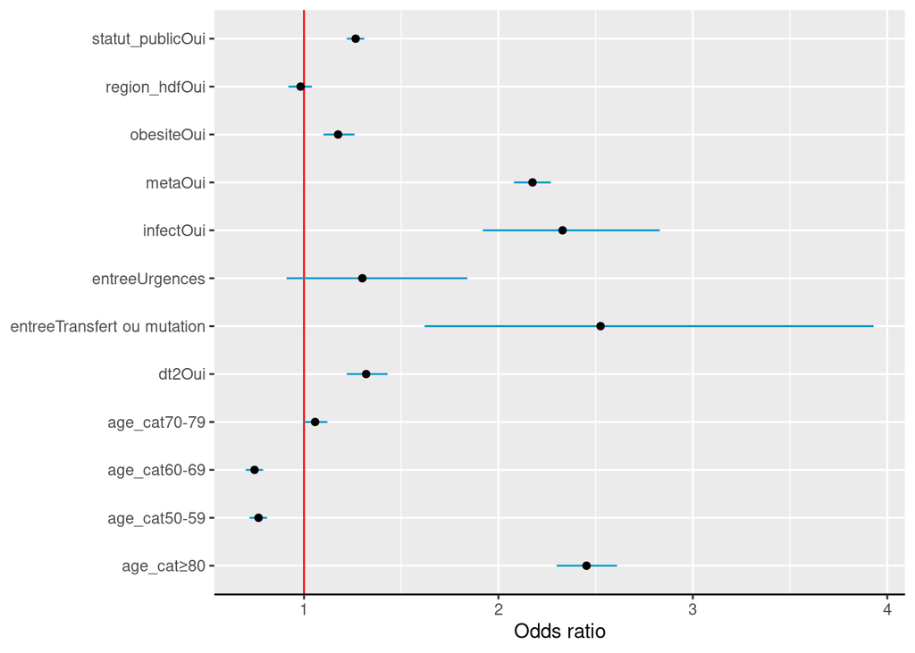

Manque de fiabilité pour les variables `entree` et `infect`, comme attendu

## 4.2 Performances

Valeur moyenne à partir des estimations faites pour chaque pli (n=10)

| .metric | estimate_ci | std_err | n |
| --- | --- | --- | --- |
| accuracy | 0.795 [0.794 ; 0.795] | 0.0003558721 | 10 |
| roc_auc | 0.637 [0.629 ; 0.645] | 0.0034235713 | 10 |

AUC moyenne : **63.7%**

# 5 Comparaison avec second modèle

Création d’un nouveau modèle multivarié, basé sur le premier avec retrait des variables sans association significative et/ou peu interprétables : `region_hdf`, `entree` et `infect` :

**modèle initial**

```
#> mastec_totale ~ age_cat + region_hdf + statut_public + entree +
#>     dt2 + obesite + infect + meta
#> <environment: 0x55a9f2634138>
```

| term | OR [IC95%] | p.value |
| --- | --- | --- |
| (Intercept) | 0.19 [0.18 ; 0.20] | <0,001 |
| age_cat50-59 | 0.77 [0.72 ; 0.81] | <0,001 |
| age_cat60-69 | 0.75 [0.71 ; 0.79] | <0,001 |
| age_cat70-79 | 1.06 [1.00 ; 1.12] | 0,046 |
| age_cat≥80 | 2.45 [2.31 ; 2.60] | <0,001 |
| region_hdfOui | 0.98 [0.93 ; 1.04] | 0,6 |
| statut_publicOui | 1.27 [1.22 ; 1.31] | <0,001 |
| entreeTransfert ou mutation | 2.52 [1.65 ; 3.82] | <0,001 |
| entreeUrgences | 1.30 [0.93 ; 1.80] | 0,12 |
| dt2Oui | 1.32 [1.22 ; 1.43] | <0,001 |
| obesiteOui | 1.18 [1.10 ; 1.26] | <0,001 |
| infectOui | 2.33 [1.93 ; 2.80] | <0,001 |
| metaOui | 2.18 [2.09 ; 2.27] | <0,001 |

| null.deviance | df.null | logLik | AIC | BIC | deviance | df.residual | nobs |
| --- | --- | --- | --- | --- | --- | --- | --- |
| 84165.28 | 82326 | -40211.36 | 80448.72 | 80569.86 | 80422.72 | 82314 | 82327 |

**modèle final**

```
#> mastec_totale ~ age_cat + statut_public + dt2 + obesite + meta
#> <environment: 0x55a974cf6920>
```

| term | OR [IC95%] | p.value |
| --- | --- | --- |
| (Intercept) | 0.19 [0.18 ; 0.20] | <0,001 |
| age_cat50-59 | 0.77 [0.72 ; 0.81] | <0,001 |
| age_cat60-69 | 0.75 [0.71 ; 0.79] | <0,001 |
| age_cat70-79 | 1.06 [1.00 ; 1.12] | 0,033 |
| age_cat≥80 | 2.49 [2.34 ; 2.64] | <0,001 |
| statut_publicOui | 1.27 [1.23 ; 1.32] | <0,001 |
| dt2Oui | 1.33 [1.23 ; 1.44] | <0,001 |
| obesiteOui | 1.19 [1.11 ; 1.27] | <0,001 |
| metaOui | 2.18 [2.09 ; 2.27] | <0,001 |

| null.deviance | df.null | logLik | AIC | BIC | deviance | df.residual | nobs |
| --- | --- | --- | --- | --- | --- | --- | --- |
| 84165.28 | 82326 | -40262.12 | 80542.25 | 80626.11 | 80524.25 | 82318 | 82327 |

AIC et BIC non minimisées : ne semble pas meilleur que le modèle initial

# 6 Scripts

## 6.1 Setup

```r
library(tidyverse)
library(tidymodels)
library(rlang)
library(glue)
library(gtsummary)
library(hebstr)

setwd("~/commun/emmanuel_chazard/RECHERCHE_2024-07-02_nicolas_penel_aap_ruban_rose")

load("data_r/sejours_analysables.RData")

set.seed(1234)

### -----------------------------------------------------------------------------

find_code <- \(class, string) {

  atih_terminologie[[enexpr(class)]] |>
    filter(str_starts(code, string)) |>
    pull(code)

}

.str <- \(class, code) expr(str_detect(!!enexpr(class), str_u(.code[[!!code]])))

easy_bin <- \(cond) if_else(cond, "Oui", "Non") |> factor()

### -----------------------------------------------------------------------------

.labels <-
lst(age = "Âge, années",
    age_cat = age,
    region_hdf = "Région Hauts-de-France",
    departement_hdf = "Départements Hauts-de-France",
    statut_public = "Établissement public",
    entree = "Mode d'entrée",
    dt2 = "Diabète de type 2",
    obesite = "Obésité",
    infect = "Épisode infectieux intercurrent",
    meta = "Métastases")

.code <-
list(k_sein = find_code(cim10, "C50"),
     dt2 = find_code(cim10, "E11"),
     obesite = find_code(cim10, "E66"),
     infect = find_code(cim10, "A|B"),
     meta = find_code(cim10, "C7([7-9])"),
     mastec = find_code(ccam, "QEFA0"),
     mastec_totale = find_code(ccam, "QEFA0(03|05|10|12|13|15|19|20)"),
     mastec_partielle = find_code(ccam, "QEFA0(0[1-2]|04|06|0[7-9]|11|14|1[6-8])"))

.atcd <-
c("dt2", "obesite", "meta") |>
  set_names() |>
  map(~ data$antécédent |>
        filter(!!.str(liste_diag, .)) |>
        pull(ano))

.mastec <-
exprs(mastec =
        easy_bin(!!.str(liste_act, "mastec")),
      mastec_totale =
        easy_bin(!!.str(liste_act, "mastec_totale")),
      mastec_partielle =
        easy_bin(!!.str(liste_act, "mastec_partielle")),
      mastec_final =
        case_when(mastec == "Oui" & mastec_totale == "Oui" ~ "Totale",
                  mastec == "Oui" & mastec_totale == "Non" ~ "Partielle",
                  .default = NA))

### FLOWCHART ------------------------------------------------------------------

data_flow_start <-
data_flow |>
  as_tibble() |>
  filter(inclus,
         str_detect(liste_diag, str_u(.code$k_sein)),
         annee_source != 2019)

data_flow_end <-
data_flow_start |>
  mutate(codegeo = str_extract(codegeo, ".{2}"),
         region =
           case_when(codegeo %in% c("59", "62", "80", "60", "02") ~ "hdf",
                     str_starts(codegeo, "9([7-9]|[:upper:])") ~ "domtom",
                     is.na(codegeo) ~ "inconnu",
                     .default = "autre"),
         !!!.mastec) |>
  flow_filter("sexe féminin" = sexe == 2,
              "entre 18 et 99 ans" = age >= 18 & age < 100,
              "en France Métropolitaine" = region != "domtom",
              "acte de mastectomie totale ou partielle" = !is.na(mastec_final))

.flow <-
lst(lib_start =
      glue("ensemble des séjours :
           - premier séjour chirurgical
           - codé cancer du sein (C50*)"),
    lib_next = imap(flow, ~ glue("{.y}\nn={.x}")),
    n = map(c(non = 1, oui = 2), ~ count(data_flow_end, mastec_totale)$n[.]),
    p = map(n, ~ percent(. / nrow(data_flow_start), accuracy = .1)),
    np = map2(n, p, ~ glue("{.x} ({.y})")),
    chart =
      DiagrammeR::grViz("

        digraph {

        graph []

        node [shape = box,
              width = 3.5,
              color = '#0099cc']

        a [label = '@@1']
        b [label = '@@2']
        c [label = '@@3']
        d [label = '@@4']
        e [label = '@@5']
        f [label = '@@6']
        g [label = '@@7']

        a -> b -> c -> d -> e
        e -> f
        e -> g

        }

        [1]: glue('{lib_start}\\nn={flow[[1]]}')
        [2]: lib_next[[2]]
        [3]: lib_next[[3]]
        [4]: lib_next[[4]]
        [5]: lib_next[[5]]
        [6]: glue('mastectomie totale\\n{np$oui}')
        [7]: glue('mastectomie partielle\\n{np$non}')

      "))

### RECODE ------------------------------------------------------------------

df_recode <-
data$index |>
  mutate(region_hdf =
           easy_bin(region == "hdf"),
         departement_hdf =
           if_else(region == "hdf", codegeo, NA) |> fct_infreq(),
         statut_public =
           easy_bin(statut_public),
         dt2 =
           easy_bin(!!.str(liste_diag, "dt2") | ano %in% .atcd$dt2),
         obesite =
           easy_bin(!!.str(liste_diag, "obesite") | ano %in% .atcd$obes),
         meta =
           easy_bin(!!.str(liste_diag, "meta") & !ano %in% .atcd$meta),
         infect =
           easy_bin(!!.str(liste_diag, "infect")),
         entree =
           case_when(entree_prov == 5 ~ "urgences",
                     entree_mode %in% c(0, 6, 7) ~ "transfert ou mutation",
                     .default = "domicile") |>
             fct_relabel(str_to_sentence),
         !!!.mastec) |>
  easy_cut(var = age,
           values = c(50, 60, 70, 80),
           labels = c("18-49", "50-59", "60-69", "70-79", "≥80")) |>
  easy_fct(departement_hdf,
           "Nord (59)" = "59",
           "Pas-de-Calais (62)" = "62",
           "Picardie (60)" = "60",
           "Somme (80)" = "80",
           "Aisne (02)" = "02") |>
  filter(!!.str(liste_diag, "k_sein"),
         annee != 2019)

df <- df_recode |> drop_na(mastec_final)

### OPTS (paramètres communs aux tableaux) -------------------------------------

theme_gtsummary_language("fr",
                         big.mark = " ",
                         decimal.mark = ",")

opts <-
lst(set = opts_set(fr = TRUE,
                   font =
                     list(alpha = "DejaVu Sans",
                          digit = "DejaVu Sans")),
    acro =
      opts_acro(IQR ~ "intervalle interquartile",
                sep = set$sep$int),
    tab =
      list(note =
             list(mastec =
                    "Les actes successifs de mastectomie partielle puis
                    totale chez une même patiente sont considérés comme
                    un acte de mastectomie totale.",
                  comorb =
                    list(vars = c("dt2", "obesite"),
                         note =
                           "Diagnostiqué lors du séjour index
                           ou d'un séjour antérieur."),
                  meta =
                    list(vars = "meta",
                         note =
                           "Découverte d'au moins un site métastatique lors du
                           séjour index, toutes localisations confondues."),
                  entree =
                    exprs(rows =
                            variable == "entree" & label == "Transfert ou mutation",
                          note = "Depuis un autre établissement.")),
           theme =
             list(acro_list = acro,
                  acro_sep = set$sep$ext,
                  alpha = set$font$alpha,
                  digit = set$font$digit,
                  color = set$pal$c[1])))

rm(list = str_subset(ls(), "data_(sejour|flow)"))
gc()

#exécution des scripts en aval
easy_source("scripts_r")
```

## 6.2 Modèle

```r
### VERIF LOGIT-LINEAR

logit_lty(df = df,
          y = mastec_totale,
          x = age,
          breaks = 40)

### CREATION MODELE --------------------------------------------------------------

model <-
lst(data = df,
    y = "mastec_totale",
    x = c("age_cat", "region_hdf", "statut_public", "entree",
          "dt2", "obesite", "infect", "meta"),
    recipe = reformulate(x, y),
    mv = glm(recipe, family = binomial, data = data),
    tidy = tidy(mv, exponentiate = TRUE, conf.int = TRUE),
    na = str_na_mv(data[, x]),
    cv = vfold_cv(data, v = 10, strata = all_of(y)))

### CV COEF -----------------------------------------------------------------------

model$coef <-
lst(data =
      model$cv |>
        mutate(model =
                 map(splits,
                     ~ glm(data = ., model$recipe, family = binomial) |>
                       tidy(exponentiate = TRUE, conf.int = TRUE))) |>
        unnest(model) |>
        summarise(mean_estimate = mean(estimate),
                  mean_conf.low = round(mean(conf.low), 2),
                  mean_conf.high = round(mean(conf.high), 2),
                  prop_significant = mean(p.value < opts$set$pvalue$seuil),
                  .by = term),
    plot =
      data |>
        filter(term != "(Intercept)") |>
        ggplot() +
        aes(x = mean_estimate,
            y = term) +
        geom_vline(xintercept = 1,
                   color = "red") +
        geom_linerange(aes(xmin = mean_conf.low,
                           xmax = mean_conf.high),
                       color = "#0099cc") +
        geom_point() +
        labs(y = NULL,
             x = "Odds ratio") +
        theme(axis.line.x = element_line(linetype = "solid")))

### CV METRICS --------------------------------------------------------------------

model$metrics <-
lst(resamples =
      workflow() |>
        add_model(set_engine(logistic_reg(), "glm")) |>
        add_recipe(recipe(model$data, model$recipe)) |>
        fit_resamples(resamples = model$cv,
                      metrics = metric_set(accuracy, roc_auc)),
    summary =
      resamples |>
        collect_metrics() |>
        mutate(conf.low = mean - qt(0.975, df = n - 1) * std_err,
               conf.high = mean + qt(0.975, df = n - 1) * std_err))
```

## 6.3 Tableaux

### 6.3.1 Tableau descriptif

```r
.t <-
lst(data =
      df |>
        select("mastec_totale", "age", "age_cat", "region_hdf", "departement_hdf",
               "statut_public", "entree", "dt2", "obesite", "infect", "meta") |>
        show_single_row() |>
        mutate(mastec_totale =
                 mastec_totale |>
                   fct_recode("Totale" = "Oui",
                              "Partielle" = "Non") |>
                   fct_rev() |>
                   labelled::set_variable_labels("Mastectomie")),
    descr = easy_descr(data, fr = TRUE))

.t$data |>
  tbl_summary(by = "mastec_totale",
              statistic =
                list(.t$de$qt$vars$para ~ .t$de$qt$stat$mean_sd,
                     .t$de$qt$vars$nonpara ~ .t$de$qt$stat$median_iqr,
                     all_categorical() ~ .t$de$ql$stat$n_pct),
              digits =
                list(all_continuous() ~ 1,
                     all_categorical() ~ c(0, 1)),
              label = .labels,
              missing = "no") |>
  # add_p(test =
  #         list(all_continuous() ~ "quanti.test",
  #              all_categorical() ~ "quali.test"),
  #       pvalue_fun = opts$set$pvalue$format) |>
  add_stat_label(label =
                   list(.t$de$qt$vars$para ~
                          str_cap(tolower, names(.t$de$qt$stat$mean)),
                        .t$de$qt$vars$nonpara ~
                          str_cap(tolower, names(.t$de$qt$stat$median)))) |>
  gtsum_format(label_header = opts$set$labs$header,
               label_overall = "**Overall**") |>
  remove_row_type(variables = departement_hdf,
                  type = "header") |>
  gt_format(note_global = opts$tab$note$mastec,
            width = 680,
            !!!opts$tab$theme) |>
  add_note(vars = "region_hdf",
           note =
             "Pourcentage des sous-catégories calculé sur
             la base de l'effectif total de la région.") |>
  add_note(!!!opts$tab$note$entree) |>
  add_note(!!!opts$tab$note$comorb) |>
  add_note(!!!opts$tab$note$meta) |>
  inject() |>
  easy_out("tab_bv")
```

### 6.3.2 Tableau de régression

```r
list(tbl_uvregression(data = model$data,
                      y = model$y,
                      include = model$x,
                      method = glm,
                      method.args = list(family = binomial),
                      hide_n = TRUE,
                      !!!opts$tab$args),
     tbl_regression(x = model$mv,
                    !!!opts$tab$args)) |>
  map(~ . |>
        gtsum_format(ci = opts$set$ci,
                     model_mv = model$mv,
                     label_header = opts$set$labs$header,
                     estim_sep = opts$set$sep$int,
                     bold_p = opts$set$pvalue$seuil) |>
        add_global_p()) |>
  tbl_merge(tab_spanner = glue("**Analyse {c('bivariée', 'multivariée')}**")) |>
  gt_format(note_global =
              glue("L'évènement est défini par la réalisation d'un acte de
                   mastectomie totale. {opts$tab$note$mastec} Modèle de régression
                   logistique multivarié incluant {model$na}. P-value en gras si
                   inférieure ou égale au seuil {opts$set$pvalue$seuil}."),
            width = 750,
            !!!opts$tab$theme) |>
  add_note(pvalue_mv = 1,
           note = "Ajustement sur tous les facteurs inclus dans l'analyse bivariée.") |>
  add_note(!!!opts$tab$note$comorb) |>
  add_note(!!!opts$tab$note$meta) |>
  add_note(!!!opts$tab$note$entree) |>
  inject() |>
  easy_out("tab_glm")
```